# S8 RQ3: imputation diagnostics (inclusive imputation)

## Description

Diagnostics for the inclusive multiple imputation used in RQ3 (`8_rq6_1a` to `8_rq6_1c`). The results of the imputation (attritioned + imputed vs original) are in `8_rq6_3_imputation_results.qmd`. The same diagnostics for the quickpred imputation are in `15_quickpred_5_imputation_diagnostics.qmd`.

This document shows:

1. **Proportion of usable cases** for each outcome’s auxiliary variables: how often each auxiliary variable is observed when the outcome is missing (the quantity that `mice::quickpred` thresholds with `minpuc`).
2. **Fraction of missing information (FMI)** for the outcome means and the change statistics.
3. **Convergence**: trace plots of the imputed values of the outcomes and of all auxiliary variables.
4. **Correlation matrix** of the variables in the imputation models.

## Load Data

```r
source("0_load_data_with_pgs.R")                                                # 0_load_data.R + the 12 PGS used as auxiliary variables (rq6z_pgs_vars)

df = df %>%
  filter(!(randomfamid %in% exclude_fams_rq1x)) %>%
  filter(!(randomfamid %in% exclude_fams_onesib)) %>%
  filter(!(randomfamid %in% exclude_fams_rq6y))

## range of participation outcomes to use for attrition

range_participation_outcomes = 6:9

# Subset vectors to only include participation outcomes in range
rq1y_twin                         = rq1y_twin[range_participation_outcomes]
rq1y_twin1                        = rq1y_twin1[range_participation_outcomes]
rq1y_twin2                        = rq1y_twin2[range_participation_outcomes]
rq1y_twin_labels                  = rq1y_twin_labels[range_participation_outcomes]
rq1y_twin_labels_clean            = rq1y_twin_labels_clean[range_participation_outcomes]
rq1y_twin_labels_clean_extrashort = rq1y_twin_labels_clean_extrashort[range_participation_outcomes]

boot_compare_results = readRDS(file.path("results",        "8_rq6_boot_compare_results.Rds"))
imputed_mice         = readRDS(file = file.path("results", "8_1_imputed_mice.Rds"))
tasks                = readRDS(file = file.path("results", "8_1_tasks.Rds")) %>%
  mutate(i = 1:nrow(.))
combine_input        = readRDS(file.path("results", "8_1_combine_input.Rds"))   # attritioned datasets, as passed to the imputation

rq6_imputation_vars = c(rq6y_all, rq6z_vars, rq6z_pgs_vars)

gc()

# Number of imputations per timepoint
n_imputations = length(boot_compare_results)/length(range_participation_outcomes)
```

## Proportion of usable cases

For an outcome *y* and an auxiliary variable *x*, the proportion of usable cases is the proportion of the cases with *y* missing in which *x* is observed (van Buuren, 2018, section 6.2). A predictor can only inform the imputation of *y* through cases where it is observed: when it is mostly missing where *y* is missing, *y* is imputed from *x*’s own imputed values. `mice::quickpred(minpuc = .25)`, used in the quickpred variant (`15_quickpred_1`), removes predictors with a proportion below .25; the inclusive imputation uses all predictors.

The proportions are computed on the attritioned datasets passed to the imputation (pooled over the sex-zygosity groups), where *y* is missing either because of attritioning or because it was never observed. Twin 1 outcomes are shown; the twin 2 outcomes are near-identical.

```r
attritioned_datasets = combine_input$attritioned_datasets                       # one data frame per attrition time point, named by rq1y_twin
aux_vars             = c(rq6z_vars, rq6z_pgs_vars)
tp_labels            = setNames(rq1y_twin_labels_clean_extrashort, rq1y_twin)

puc = imap_dfr(attritioned_datasets, function(d, tp) {
  map_dfr(rq6y_all, function(y) {
    y_missing = is.na(d[[y]])
    tibble(
      timepoint = tp_labels[[tp]],
      outcome   = y,
      n_missing = sum(y_missing),
      variable  = aux_vars,
      puc       = colMeans(!is.na(d[y_missing, aux_vars, drop = FALSE]))      # P(x observed | y missing)
    )
  })
}) %>%
  mutate(timepoint = factor(timepoint, levels = rq1y_twin_labels_clean_extrashort))

testthat::test_that("Usable-case proportions computed for every time point, outcome and auxiliary variable", {
  testthat::expect_equal(nrow(puc), length(rq1y_twin) * length(rq6y_all) * length(aux_vars))
  testthat::expect_true(all(puc$puc >= 0 & puc$puc <= 1))
})
```

```
Test passed 😸
```

```r
# Study wave of each auxiliary variable (TEDS prefix = age of data collection)
wave_of = function(v) case_when(
  str_detect(v, "^pgs_") ~ "Polygenic scores",
  str_detect(v, "^cens") ~ "First contact (postcode-linked)",
  v == "cohort"          ~ "First contact",
  str_detect(v, "^a")    ~ "First contact",
  str_detect(v, "^b")    ~ "Age 2",
  str_detect(v, "^c")    ~ "Age 3",
  str_detect(v, "^d")    ~ "Age 4",
  str_detect(v, "^g")    ~ "Age 7",
  str_detect(v, "^h")    ~ "Age 8",
  str_detect(v, "^i")    ~ "Age 9",
  str_detect(v, "^j")    ~ "Age 10",
  str_detect(v, "^l")    ~ "Age 12",
  str_detect(v, "^n")    ~ "Age 14",
  str_detect(v, "^p")    ~ "Age 16",
  str_detect(v, "^r")    ~ "Age 18",
  str_detect(v, "^u")    ~ "Age 21",
  str_detect(v, "^z")    ~ "Age 26",
  TRUE                   ~ "Other"
)
wave_levels = c("First contact", "First contact (postcode-linked)", paste("Age", c(2, 3, 4, 7, 8, 9, 10, 12, 14, 16, 18, 21, 26)), "Polygenic scores", "Other")
```

### Summary

Number of auxiliary variables (of 125) below the `minpuc` threshold of .25, for each outcome and attrition time point.

```r
n_aux = length(aux_vars)
n_pgs = sum(str_detect(aux_vars, "^pgs_"))

puc %>%
  filter(outcome %in% rq6y) %>%
  group_by(timepoint, outcome) %>%
  summarise(
    n_missing    = first(n_missing),
    below_25     = paste0(sum(puc < .25), "/", n_aux),
    below_25_pgs = paste0(sum(puc < .25 & str_detect(variable, "^pgs_")), "/", n_pgs),
    below_10     = paste0(sum(puc < .10), "/", n_aux),
    median_puc   = median(puc),
    .groups = "drop"
  ) %>%
  mutate(outcome = factor(rq6y_labels[match(outcome, rq6y)], levels = rq6y_labels)) %>%
  arrange(timepoint, outcome) %>%
  gt(groupname_col = "timepoint", rowname_col = "outcome") %>%
  fmt_percent(columns = median_puc, decimals = 0) %>%
  fmt_integer(columns = n_missing) %>%
  cols_label(
    n_missing    = md("Families with<br>outcome missing"),
    below_25     = md("Auxiliary variables<br>observed for < 25%"),
    below_25_pgs = md("PGS<br>observed for < 25%"),
    below_10     = md("Auxiliary variables<br>observed for < 10%"),
    median_puc   = md("Median % observed<br>(all auxiliary variables)")
  ) %>%
  cols_align("center", columns = -outcome) %>%
  tab_spanner("Among the families with the outcome missing:", columns = c(below_25, below_25_pgs, below_10, median_puc)) %>%
  tab_style(style = cell_text(size = px(12)), locations = list(cells_body(), cells_stub(), cells_column_labels(), cells_column_spanners(), cells_row_groups())) %>%
  tab_footnote(md(paste0(
    "Twin 1 outcomes, by attrition time point. For each outcome, the auxiliary variables are counted by how often they are observed ",
    "among the families whose outcome is missing (the proportion of usable cases). For example, 13/", n_aux, " means that 13 of the ",
    n_aux, " auxiliary variables are observed for fewer than 25% of these families. `quickpred(minpuc = .25)` would remove these as predictors ",
    "of the outcome. The PGS column counts the ", n_pgs, " PGS (twin and co-twin) separately.")))
```

|  | Families with outcome missing | Among the families with the outcome missing: Auxiliary variables observed for < 25% | Among the families with the outcome missing: PGS observed for < 25% | Among the families with the outcome missing: Auxiliary variables observed for < 10% | Among the families with the outcome missing: Median % observed (all auxiliary variables) |
| --- | --- | --- | --- | --- | --- |
| Y21 |  |  |  |  |  |
| Y12: Depression (MFQ) | 4,204 | 13/125 | 0/24 | 0/125 | 43% |
| Y12: Externalising (SDQ) | 4,215 | 13/125 | 0/24 | 0/125 | 43% |
| Y12: Cognitive ability | 4,871 | 6/125 | 0/24 | 0/125 | 47% |
| Y16: GCSE grade | 3,766 | 18/125 | 0/24 | 1/125 | 41% |
| Y26 (q'aire) |  |  |  |  |  |
| Y12: Depression (MFQ) | 4,754 | 10/125 | 0/24 | 0/125 | 47% |
| Y12: Externalising (SDQ) | 4,761 | 9/125 | 0/24 | 0/125 | 48% |
| Y12: Cognitive ability | 5,304 | 7/125 | 0/24 | 0/125 | 50% |
| Y16: GCSE grade | 4,400 | 9/125 | 0/24 | 3/125 | 46% |
| Y26 (web test) |  |  |  |  |  |
| Y12: Depression (MFQ) | 6,220 | 0/125 | 0/24 | 0/125 | 54% |
| Y12: Externalising (SDQ) | 6,224 | 0/125 | 0/24 | 0/125 | 54% |
| Y12: Cognitive ability | 6,453 | 0/125 | 0/24 | 0/125 | 55% |
| Y16: GCSE grade | 6,040 | 0/125 | 0/24 | 0/125 | 54% |
| Genotyped |  |  |  |  |  |
| Y12: Depression (MFQ) | 2,999 | 19/125 | 0/24 | 0/125 | 41% |
| Y12: Externalising (SDQ) | 3,018 | 19/125 | 0/24 | 0/125 | 41% |
| Y12: Cognitive ability | 4,127 | 8/125 | 0/24 | 0/125 | 48% |
| Y16: GCSE grade | 2,674 | 8/125 | 0/24 | 0/125 | 36% |

Twin 1 outcomes, by attrition time point. For each outcome, the auxiliary variables are counted by how often they are observed among the families whose outcome is missing (the proportion of usable cases). For example, 13/125 means that 13 of the 125 auxiliary variables are observed for fewer than 25% of these families. `quickpred(minpuc = .25)` would remove these as predictors of the outcome. The PGS column counts the 24 PGS (twin and co-twin) separately.

### By auxiliary variable

Proportion of usable cases for every auxiliary variable (rows) and twin 1 outcome (columns), at each attrition time point. Red: below .25 (removed by `quickpred(minpuc = .25)`). Twin-specific auxiliary variables have a twin 1 and a twin 2 row.

```r
puc_wide = puc %>%
  filter(outcome %in% rq6y) %>%
  mutate(col = paste(timepoint, outcome, sep = "__")) %>%
  select(variable, col, puc) %>%
  pivot_wider(names_from = col, values_from = puc) %>%
  mutate(
    label = sapply(var_to_label(variable), function(x) ifelse(is.null(x[1]), "", x[1])),
    wave  = factor(wave_of(variable), levels = wave_levels)
  ) %>%
  arrange(wave, match(variable, aux_vars)) %>%
  relocate(wave, variable, label)

puc_cols = setdiff(colnames(puc_wide), c("wave", "variable", "label"))

puc_wide %>%
  gt(groupname_col = "wave", rowname_col = "variable") %>%
  fmt_number(columns = all_of(puc_cols), decimals = 2) %>%
  tab_spanner_delim(delim = "__", columns = all_of(puc_cols)) %>%
  cols_label_with(columns = all_of(puc_cols), fn = function(x) rq6y_labels[match(x, rq6y)] %>% str_remove("^Y1\\d: ")) %>%
  cols_label(label = "Description") %>%
  cols_width(label ~ px(260)) %>%
  tab_style(
    style     = list(cell_fill(color = "#f8cecc"), cell_text(color = "#a50f15")),
    locations = lapply(puc_cols, function(cl) cells_body(columns = all_of(cl), rows = puc_wide[[cl]] < .25))
  ) %>%
  tab_style(style = cell_text(weight = "bold"), locations = cells_row_groups()) %>%
  tab_style(style = cell_text(font = "monospace", size = "small"), locations = cells_stub()) %>%
  tab_options(table.font.size = "small", data_row.padding = px(1), row_group.padding = px(4))
```

|  | Description | Y21 Depression (MFQ) | Y21 Externalising (SDQ) | Y21 Cognitive ability | Y21 GCSE grade | Y26 (q'aire) Depression (MFQ) | Y26 (q'aire) Externalising (SDQ) | Y26 (q'aire) Cognitive ability | Y26 (q'aire) GCSE grade | Y26 (web test) Depression (MFQ) | Y26 (web test) Externalising (SDQ) | Y26 (web test) Cognitive ability | Y26 (web test) GCSE grade | Genotyped Depression (MFQ) | Genotyped Externalising (SDQ) | Genotyped Cognitive ability | Genotyped GCSE grade |
| --- | --- | --- | --- | --- | --- | --- | --- | --- | --- | --- | --- | --- | --- | --- | --- | --- | --- |
| First contact |  |  |  |  |  |  |  |  |  |  |  |  |  |  |  |  |  |
| cohort | School cohort, see value labels | 1.00 | 1.00 | 1.00 | 1.00 | 1.00 | 1.00 | 1.00 | 1.00 | 1.00 | 1.00 | 1.00 | 1.00 | 1.00 | 1.00 | 1.00 | 1.00 |
| amumagetw | Age in years of natural mother at time of birth of twins | 0.98 | 0.98 | 0.98 | 0.98 | 0.98 | 0.98 | 0.99 | 0.98 | 0.99 | 0.99 | 0.99 | 0.99 | 0.98 | 0.98 | 0.98 | 0.98 |
| asingle | Single Parent | 0.99 | 0.99 | 0.99 | 0.98 | 0.98 | 0.98 | 0.99 | 0.98 | 0.99 | 0.99 | 0.99 | 0.99 | 0.99 | 0.99 | 0.99 | 0.98 |
| amosoc2 | Mother SOC employment level (1st Contact), 1-9 | 0.98 | 0.98 | 0.98 | 0.98 | 0.98 | 0.98 | 0.98 | 0.98 | 0.99 | 0.99 | 0.99 | 0.99 | 0.99 | 0.99 | 0.98 | 0.99 |
| amohqualn | Maternal Education (formatted as numeric) | 0.99 | 0.99 | 0.99 | 0.99 | 0.99 | 0.99 | 0.99 | 0.99 | 0.99 | 0.99 | 0.99 | 0.99 | 0.99 | 0.99 | 0.99 | 0.99 |
| aethnic | Ethnic origin of twins, simplified coding (1st Contact), 1=white 0=other | 1.00 | 1.00 | 1.00 | 1.00 | 1.00 | 1.00 | 1.00 | 1.00 | 1.00 | 1.00 | 1.00 | 1.00 | 1.00 | 1.00 | 1.00 | 1.00 |
| alang | Main language spoken at home (1st Contact), see value labels | 0.99 | 0.99 | 0.99 | 0.99 | 0.99 | 0.99 | 0.99 | 0.99 | 0.99 | 0.99 | 0.99 | 0.99 | 0.99 | 0.99 | 0.99 | 0.99 |
| anoldsibn | Number of older siblings (formatted as numeric variable) | 1.00 | 1.00 | 1.00 | 1.00 | 1.00 | 1.00 | 1.00 | 1.00 | 1.00 | 1.00 | 1.00 | 1.00 | 1.00 | 1.00 | 1.00 | 1.00 |
| anyngsibn | Number of younger siblings (formatted as numeric variable) | 1.00 | 1.00 | 1.00 | 1.00 | 1.00 | 1.00 | 1.00 | 1.00 | 1.00 | 1.00 | 1.00 | 1.00 | 1.00 | 1.00 | 1.00 | 1.00 |
| atwclub | Member of a Twins Club (1st Contact), 1Y 0N | 0.95 | 0.95 | 0.96 | 0.96 | 0.96 | 0.96 | 0.96 | 0.96 | 0.96 | 0.96 | 0.96 | 0.96 | 0.95 | 0.95 | 0.96 | 0.96 |
| asmoke | Smoked cigarettes while pregnant (1st Contact), 1Y 0N | 1.00 | 1.00 | 1.00 | 0.99 | 1.00 | 1.00 | 1.00 | 1.00 | 1.00 | 1.00 | 1.00 | 1.00 | 1.00 | 1.00 | 1.00 | 1.00 |
| First contact (postcode-linked) |  |  |  |  |  |  |  |  |  |  |  |  |  |  |  |  |  |
| cens01pop98density | Census data 2001 (code KS001) linked to 1998 postcode: population density, N per hectare | 0.32 | 0.32 | 0.33 | 0.31 | 0.33 | 0.33 | 0.34 | 0.32 | 0.34 | 0.34 | 0.34 | 0.34 | 0.33 | 0.33 | 0.35 | 0.30 |
| Age 4 |  |  |  |  |  |  |  |  |  |  |  |  |  |  |  |  |  |
| drawg1 | G: overall cognitive ability composite (4 Year), standardised | 0.65 | 0.65 | 0.68 | 0.68 | 0.68 | 0.68 | 0.69 | 0.70 | 0.71 | 0.71 | 0.72 | 0.72 | 0.61 | 0.61 | 0.66 | 0.66 |
| drawg2 | G: overall cognitive ability composite (4 Year), standardised | 0.65 | 0.65 | 0.68 | 0.68 | 0.68 | 0.68 | 0.70 | 0.70 | 0.71 | 0.71 | 0.72 | 0.72 | 0.61 | 0.61 | 0.66 | 0.66 |
| dsdqcont1 | SDQ Conduct scale (4 Year), 0-10 | 0.67 | 0.67 | 0.70 | 0.70 | 0.70 | 0.70 | 0.71 | 0.72 | 0.73 | 0.73 | 0.74 | 0.74 | 0.63 | 0.63 | 0.68 | 0.68 |
| dsdqcont2 | SDQ Conduct scale (4 Year), 0-10 | 0.67 | 0.67 | 0.70 | 0.70 | 0.70 | 0.70 | 0.71 | 0.72 | 0.73 | 0.73 | 0.74 | 0.74 | 0.63 | 0.63 | 0.68 | 0.68 |
| dsdqhypt1 | SDQ Hyperactivity scale (4 Year), 0-10 | 0.67 | 0.67 | 0.70 | 0.70 | 0.70 | 0.70 | 0.71 | 0.72 | 0.73 | 0.73 | 0.74 | 0.74 | 0.63 | 0.63 | 0.68 | 0.68 |
| dsdqhypt2 | SDQ Hyperactivity scale (4 Year), 0-10 | 0.67 | 0.67 | 0.70 | 0.70 | 0.70 | 0.70 | 0.71 | 0.72 | 0.73 | 0.73 | 0.74 | 0.74 | 0.63 | 0.63 | 0.68 | 0.68 |
| danxt1 | ARBQ total scale (4 Year), 0-36 | 0.67 | 0.67 | 0.70 | 0.70 | 0.70 | 0.70 | 0.71 | 0.72 | 0.73 | 0.73 | 0.74 | 0.74 | 0.63 | 0.63 | 0.68 | 0.68 |
| danxt2 | ARBQ total scale (4 Year), 0-36 | 0.67 | 0.67 | 0.70 | 0.70 | 0.70 | 0.70 | 0.71 | 0.72 | 0.73 | 0.73 | 0.74 | 0.74 | 0.63 | 0.63 | 0.68 | 0.68 |
| dchatot | Chaos overall scale (4 Year), standardised | 0.68 | 0.68 | 0.70 | 0.70 | 0.70 | 0.70 | 0.72 | 0.73 | 0.74 | 0.74 | 0.74 | 0.75 | 0.63 | 0.64 | 0.69 | 0.68 |
| Age 7 |  |  |  |  |  |  |  |  |  |  |  |  |  |  |  |  |  |
| gcg1 | Child G composite (7 year twin phone), standardised | 0.50 | 0.50 | 0.52 | 0.52 | 0.51 | 0.51 | 0.52 | 0.53 | 0.53 | 0.53 | 0.53 | 0.53 | 0.46 | 0.46 | 0.51 | 0.49 |
| gcg2 | Child G composite (7 year twin phone), standardised | 0.50 | 0.51 | 0.52 | 0.53 | 0.51 | 0.51 | 0.52 | 0.53 | 0.52 | 0.52 | 0.53 | 0.53 | 0.46 | 0.47 | 0.51 | 0.49 |
| gt2ac1 | 2-subject (maths, English) mean NC level (7 year teacher), 0-4 | 0.57 | 0.57 | 0.59 | 0.60 | 0.59 | 0.59 | 0.60 | 0.61 | 0.63 | 0.63 | 0.63 | 0.63 | 0.51 | 0.51 | 0.57 | 0.56 |
| gt2ac2 | 2-subject (maths, English) mean NC level (7 year teacher), 0-4 | 0.57 | 0.57 | 0.59 | 0.60 | 0.59 | 0.59 | 0.60 | 0.61 | 0.63 | 0.63 | 0.63 | 0.64 | 0.51 | 0.51 | 0.57 | 0.56 |
| gpsdqhypt1 | SDQ hyperactivity total (7 year parent), 0-10 | 0.72 | 0.72 | 0.74 | 0.76 | 0.74 | 0.74 | 0.76 | 0.77 | 0.78 | 0.78 | 0.78 | 0.79 | 0.66 | 0.66 | 0.72 | 0.72 |

[output cut: 108 more lines]

## Imputation diagnostics

### Fraction of Missing Information

#### Calculation for **sample means**

Here, we calculate the fraction of missing information (FMI) for each variable mean.

Because imputation is performed separately at each attrition timepoint, the FMI differs across timepoints. FMI is higher when more data is missing at the attrition timepoint (i.e., fewer participants at that wave).

```r
timepoint_labels = rq1y_twin_labels_clean

fmi_original = map_dfr(seq_along(imputed_mice), function(tp) {
  map_dfr(rq6y, function(v) {                                                                                      # starts loop for each
    # browser()                                                                                                    # For checking this code...

    Q = sapply(imputed_mice[[tp]], function(df) mean(df[[v]], na.rm = TRUE))                                       # For variable v, this is a vector of K imputed means
    U = sapply(imputed_mice[[tp]], function(df) stats::var(df[[v]], na.rm = TRUE) / sum(!is.na(df[[v]])))          # For variable v, this is a vector of K sample mean variances (imputed variance of variable)/(imputed sample size)

    result = mice::pool.scalar(Q = Q, U = U)

    tibble(
      timepoint = timepoint_labels[tp],
      variable  = v,
      estimate  = result$qbar,
      se        = sqrt(result$t),
      fmi       = result$fmi
    )
  })
})

fmi_original %>%
  mutate(variable = rq6y_labels[match(variable, rq6y)]) %>%
  gt(groupname_col = "timepoint") %>%
  fmt_number(decimals = 3) %>%
  cols_label(
    variable = "Variable",
    estimate = "Estimate",
    se       = "SE",
    fmi      = "FMI"
  ) %>%
  cols_hide(c("estimate", "se")) %>%
  tab_style(
    style    = cell_text(size = px(12)),
    locations = cells_body()
  )
```

| Variable | FMI |
| --- | --- |
| Y21 (TEDS21 phase-1 questionnaire) |  |
| Y12: Depression (MFQ) | 0.476 |
| Y12: Externalising (SDQ) | 0.369 |
| Y12: Cognitive ability | 0.277 |
| Y16: GCSE grade | 0.241 |
| Y26 (TEDS26 questionnaire) |  |
| Y12: Depression (MFQ) | 0.530 |
| Y12: Externalising (SDQ) | 0.526 |
| Y12: Cognitive ability | 0.427 |
| Y16: GCSE grade | 0.360 |
| Y26 (CATSLife web tests) |  |
| Y12: Depression (MFQ) | 0.834 |
| Y12: Externalising (SDQ) | 0.849 |
| Y12: Cognitive ability | 0.935 |
| Y16: GCSE grade | 0.783 |
| Genotyped |  |
| Y12: Depression (MFQ) | 0.287 |
| Y12: Externalising (SDQ) | 0.160 |
| Y12: Cognitive ability | 0.124 |
| Y16: GCSE grade | 0.136 |

#### Calculation for **change statistics**

Here we calculate the FMI for the change statistics (i.e., the difference between original and attritioned estimates), using bootstrap variance as the within-imputation variance.

```r
simple_params = c("md", "smd", "var")

df_long = boot_compare_results %>%
  imap_dfr(function(imp_data, imp_name) {
    imap_dfr(imp_data[simple_params], function(boot_list, param_name) {
      imap_dfr(boot_list, function(values, boot_idx) {
        tibble(
          imputation_name = imp_name,
          bootstrap = boot_idx,
          parameter = param_name,
          variable = rq6y_labels,
          value = values
        )
      })
    })
  }) %>%
  mutate(
    # Extract timepoint prefix (everything before trailing digits)
    timepoint_code = str_remove(imputation_name, "\\d+$"),
    imp_num = as.numeric(str_extract(imputation_name, "\\d+$")),
    # Map to readable timepoint labels (all four time points, incl. hasgeno)
    timepoint = factor(tp_labels[timepoint_code], levels = rq1y_twin_labels_clean_extrashort)
  ) %>%
  select(timepoint, imp_num, bootstrap, parameter, variable, value)

fmi_results = df_long %>%
  # Step 1: Get point estimate and within-imputation variance for each imputation
  group_by(timepoint, parameter, variable, imp_num) %>%
  summarise(
    Q_m          = mean(value),       # Point estimate for this imputation
    U_m          = stats::var(value), # Within-imputation variance (from bootstrap)
    n_bootstraps = dplyr::n(),
    .groups      = "drop"
  ) %>%
  # Step 2: Pool across imputations using Rubin's rules
  group_by(timepoint, parameter, variable) %>%
  summarise(
    m       = dplyr::n(),          # Number of imputations
    Q_bar   = mean(Q_m),           # Pooled point estimate
    W       = mean(U_m),           # Within-imputation variance (average)
    B       = stats::var(Q_m),     # Between-imputation variance
    .groups = "drop"
  ) %>%
  mutate(
    T          = W + B + B/m,                # Total variance
    r          = (1 + 1/m) * B / W,          # Relative increase in variance due to missingness
    df         = (m - 1) * (1 + 1/r)^2,      # Degrees of freedom (Barnard-Rubin adjusted)
    FMI        = (r + 2/(df + 3)) / (r + 1), # Fraction of Missing Information
    FMI_simple = (B + B/m) / T               # Simpler FMI approximation (lambda)
  )

fmi_results %>%
  gt(groupname_col = "timepoint") %>%
  fmt_number(decimals = 3, columns = !m)
```

| parameter | variable | m | Q_bar | W | B | T | r | df | FMI | FMI_simple |
| --- | --- | --- | --- | --- | --- | --- | --- | --- | --- | --- |
| Y21 |  |  |  |  |  |  |  |  |  |  |
| md | Y12: Cognitive ability | 250 | 0.016 | 0.000 | 0.000 | 0.000 | 0.825 | 1,218.328 | 0.453 | 0.452 |
| md | Y12: Depression (MFQ) | 250 | 0.458 | 0.001 | 0.001 | 0.003 | 1.196 | 839.534 | 0.546 | 0.545 |
| md | Y12: Externalising (SDQ) | 250 | 0.108 | 0.001 | 0.001 | 0.002 | 1.067 | 934.084 | 0.517 | 0.516 |
| md | Y16: GCSE grade | 250 | 0.056 | 0.000 | 0.000 | 0.000 | 0.811 | 1,241.630 | 0.449 | 0.448 |
| smd | Y12: Cognitive ability | 250 | 0.016 | 0.000 | 0.000 | 0.000 | 0.829 | 1,211.711 | 0.454 | 0.453 |
| smd | Y12: Depression (MFQ) | 250 | 0.137 | 0.000 | 0.000 | 0.000 | 1.073 | 929.167 | 0.519 | 0.518 |
| smd | Y12: Externalising (SDQ) | 250 | 0.031 | 0.000 | 0.000 | 0.000 | 1.055 | 944.938 | 0.514 | 0.513 |
| smd | Y16: GCSE grade | 250 | 0.046 | 0.000 | 0.000 | 0.000 | 0.827 | 1,214.487 | 0.454 | 0.453 |
| var | Y12: Cognitive ability | 250 | 0.025 | 0.000 | 0.000 | 0.000 | 0.718 | 1,425.388 | 0.419 | 0.418 |
| var | Y12: Depression (MFQ) | 250 | 0.329 | 0.001 | 0.001 | 0.002 | 0.958 | 1,040.426 | 0.490 | 0.489 |
| var | Y12: Externalising (SDQ) | 250 | 0.095 | 0.000 | 0.000 | 0.000 | 0.869 | 1,151.360 | 0.466 | 0.465 |
| var | Y16: GCSE grade | 250 | −0.021 | 0.000 | 0.000 | 0.000 | 0.573 | 1,876.687 | 0.365 | 0.364 |
| Y26 (q'aire) |  |  |  |  |  |  |  |  |  |  |
| md | Y12: Cognitive ability | 250 | 0.031 | 0.000 | 0.000 | 0.000 | 1.101 | 906.875 | 0.525 | 0.524 |
| md | Y12: Depression (MFQ) | 250 | 0.537 | 0.001 | 0.002 | 0.003 | 1.301 | 778.956 | 0.566 | 0.565 |
| md | Y12: Externalising (SDQ) | 250 | 0.162 | 0.001 | 0.001 | 0.003 | 1.438 | 715.885 | 0.591 | 0.590 |
| md | Y16: GCSE grade | 250 | 0.069 | 0.000 | 0.000 | 0.000 | 1.138 | 878.772 | 0.533 | 0.532 |
| smd | Y12: Cognitive ability | 250 | 0.031 | 0.000 | 0.000 | 0.000 | 1.110 | 899.571 | 0.527 | 0.526 |
| smd | Y12: Depression (MFQ) | 250 | 0.161 | 0.000 | 0.000 | 0.000 | 1.147 | 872.366 | 0.535 | 0.534 |
| smd | Y12: Externalising (SDQ) | 250 | 0.047 | 0.000 | 0.000 | 0.000 | 1.414 | 725.790 | 0.587 | 0.586 |
| smd | Y16: GCSE grade | 250 | 0.056 | 0.000 | 0.000 | 0.000 | 1.163 | 861.282 | 0.539 | 0.538 |
| var | Y12: Cognitive ability | 250 | 0.028 | 0.000 | 0.000 | 0.000 | 0.973 | 1,023.951 | 0.494 | 0.493 |
| var | Y12: Depression (MFQ) | 250 | 0.322 | 0.001 | 0.001 | 0.002 | 1.010 | 985.957 | 0.504 | 0.503 |
| var | Y12: Externalising (SDQ) | 250 | 0.133 | 0.000 | 0.000 | 0.001 | 1.314 | 772.189 | 0.569 | 0.568 |
| var | Y16: GCSE grade | 250 | −0.063 | 0.000 | 0.000 | 0.000 | 0.966 | 1,030.956 | 0.492 | 0.491 |
| Y26 (web test) |  |  |  |  |  |  |  |  |  |  |
| md | Y12: Cognitive ability | 250 | 0.050 | 0.000 | 0.001 | 0.002 | 7.215 | 322.809 | 0.879 | 0.878 |
| md | Y12: Depression (MFQ) | 250 | 1.175 | 0.002 | 0.007 | 0.010 | 3.414 | 416.207 | 0.775 | 0.773 |
| md | Y12: Externalising (SDQ) | 250 | 0.316 | 0.002 | 0.007 | 0.009 | 3.713 | 401.181 | 0.789 | 0.788 |
| md | Y16: GCSE grade | 250 | 0.092 | 0.000 | 0.000 | 0.001 | 3.303 | 422.582 | 0.769 | 0.768 |
| smd | Y12: Cognitive ability | 250 | 0.050 | 0.000 | 0.001 | 0.002 | 7.259 | 322.331 | 0.880 | 0.879 |
| smd | Y12: Depression (MFQ) | 250 | 0.353 | 0.000 | 0.001 | 0.001 | 2.432 | 495.900 | 0.710 | 0.709 |
| smd | Y12: Externalising (SDQ) | 250 | 0.091 | 0.000 | 0.001 | 0.001 | 3.604 | 406.373 | 0.784 | 0.783 |
| smd | Y16: GCSE grade | 250 | 0.075 | 0.000 | 0.000 | 0.000 | 3.373 | 418.538 | 0.772 | 0.771 |
| var | Y12: Cognitive ability | 250 | 0.515 | 0.001 | 0.002 | 0.003 | 2.444 | 494.499 | 0.711 | 0.710 |
| var | Y12: Depression (MFQ) | 250 | 0.581 | 0.002 | 0.005 | 0.007 | 2.258 | 518.330 | 0.694 | 0.693 |
| var | Y12: Externalising (SDQ) | 250 | 0.393 | 0.001 | 0.002 | 0.003 | 3.165 | 431.201 | 0.761 | 0.760 |
| var | Y16: GCSE grade | 250 | 0.034 | 0.000 | 0.001 | 0.001 | 3.394 | 417.330 | 0.774 | 0.772 |
| Genotyped |  |  |  |  |  |  |  |  |  |  |
| md | Y12: Cognitive ability | 250 | 0.008 | 0.000 | 0.000 | 0.000 | 0.540 | 2,023.323 | 0.351 | 0.351 |
| md | Y12: Depression (MFQ) | 250 | 0.181 | 0.001 | 0.001 | 0.001 | 1.062 | 938.555 | 0.516 | 0.515 |
| md | Y12: Externalising (SDQ) | 250 | 0.101 | 0.000 | 0.000 | 0.001 | 0.626 | 1,680.447 | 0.386 | 0.385 |
| md | Y16: GCSE grade | 250 | 0.007 | 0.000 | 0.000 | 0.000 | 0.685 | 1,505.864 | 0.407 | 0.407 |
| smd | Y12: Cognitive ability | 250 | 0.008 | 0.000 | 0.000 | 0.000 | 0.541 | 2,018.648 | 0.352 | 0.351 |
| smd | Y12: Depression (MFQ) | 250 | 0.054 | 0.000 | 0.000 | 0.000 | 1.015 | 981.421 | 0.505 | 0.504 |
| smd | Y12: Externalising (SDQ) | 250 | 0.029 | 0.000 | 0.000 | 0.000 | 0.622 | 1,694.310 | 0.384 | 0.383 |
| smd | Y16: GCSE grade | 250 | 0.006 | 0.000 | 0.000 | 0.000 | 0.687 | 1,502.111 | 0.408 | 0.407 |
| var | Y12: Cognitive ability | 250 | 0.003 | 0.000 | 0.000 | 0.000 | 0.729 | 1,400.884 | 0.422 | 0.422 |
| var | Y12: Depression (MFQ) | 250 | 0.123 | 0.001 | 0.000 | 0.001 | 0.822 | 1,224.031 | 0.452 | 0.451 |
| var | Y12: Externalising (SDQ) | 250 | 0.055 | 0.000 | 0.000 | 0.000 | 0.695 | 1,480.295 | 0.411 | 0.410 |
| var | Y16: GCSE grade | 250 | 0.000 | 0.000 | 0.000 | 0.000 | 0.561 | 1,928.622 | 0.360 | 0.359 |

### Convergence Check

```r
all_imputations      = readRDS(file = file.path("results", "8_1_all_imputations.Rds"))

ids_keep = tasks %>%
  filter(imputation <=20) %>%
  pull(i) %>% max()

all_imputations = all_imputations[1:ids_keep]

# Simple labels without spaces/special characters for plotting
simple_labels = c("Depression", "Externalising", "Cognitive", "GCSE")
new_names = c(paste0(simple_labels, "1"), paste0(simple_labels, "2"))

rename_mids = function(mids_obj,
                       old_names = rq6y_all,
                       new_names = c(paste0(simple_labels, "1"), paste0(simple_labels, "2"))) {
  for (i in seq_along(old_names)) {
    old = old_names[i]
    new = new_names[i]

    # Rename in data
    names(mids_obj$data)[names(mids_obj$data) == old] = new

    # Rename in imp list
    names(mids_obj$imp)[names(mids_obj$imp) == old] = new

    # Rename in method vector
    names(mids_obj$method)[names(mids_obj$method) == old] = new

    # Rename in predictorMatrix (both rows and columns)
    rownames(mids_obj$predictorMatrix)[rownames(mids_obj$predictorMatrix) == old] = new
    colnames(mids_obj$predictorMatrix)[colnames(mids_obj$predictorMatrix) == old] = new

    # Rename in where matrix
    if (!is.null(mids_obj$where)) {
      colnames(mids_obj$where)[colnames(mids_obj$where) == old] = new
    }

    # Rename in nmis (number of missing)
    if (!is.null(mids_obj$nmis)) {
      names(mids_obj$nmis)[names(mids_obj$nmis) == old] = new
    }

    # Rename in chainMean (first dimension) - used by plot()
    if (!is.null(mids_obj$chainMean)) {
      dn = dimnames(mids_obj$chainMean)
      dn[[1]][dn[[1]] == old] = new
      dimnames(mids_obj$chainMean) = dn
    }

    # Rename in chainVar (first dimension) - used by plot()
    if (!is.null(mids_obj$chainVar)) {
      dn = dimnames(mids_obj$chainVar)
      dn[[1]][dn[[1]] == old] = new
      dimnames(mids_obj$chainVar) = dn
    }

    # Rename in visitSequence
    if (!is.null(mids_obj$visitSequence)) {
      names(mids_obj$visitSequence)[names(mids_obj$visitSequence) == old] = new
      mids_obj$visitSequence[mids_obj$visitSequence == old] = new
    }

    # Rename in blocks
    if (!is.null(mids_obj$blocks)) {
      names(mids_obj$blocks)[names(mids_obj$blocks) == old] = new
      mids_obj$blocks = lapply(mids_obj$blocks, function(b) {
        b[b == old] = new
        b
      })
    }
  }
  return(mids_obj)
}
```

#### Timepoint: Y21 (TEDS21 phase-1 questionnaire)

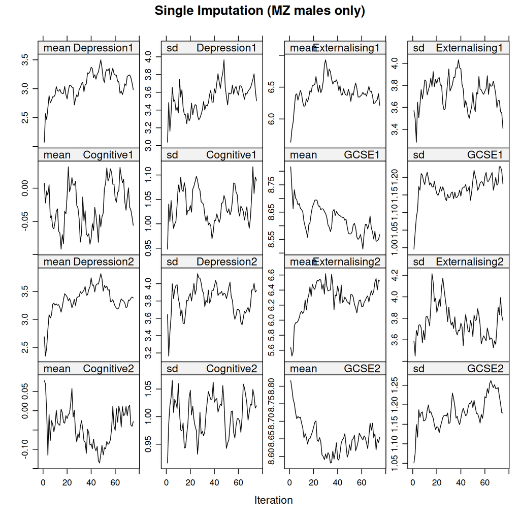

```r
ids = tasks %>%
  filter(imputation == 1) %>%
  filter(timepoint == rq1y_twin[1]) %>%
  pull(i)

combine_mids = Reduce(mice::rbind, all_imputations[ids])

all_imputations[[ids[1]]] %>%
  rename_mids() %>%
  plot(y = new_names, layout = c(4, 4), main = "Single Imputation (MZ males only)")
```

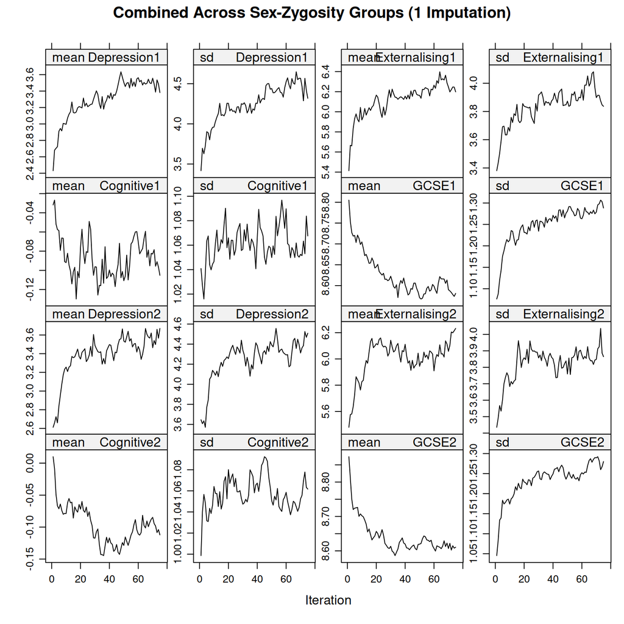

```r
combine_mids %>%
  rename_mids() %>%
  plot(y = new_names, layout = c(4, 4), main = "Combined Across Sex-Zygosity Groups (1 Imputation)")
```

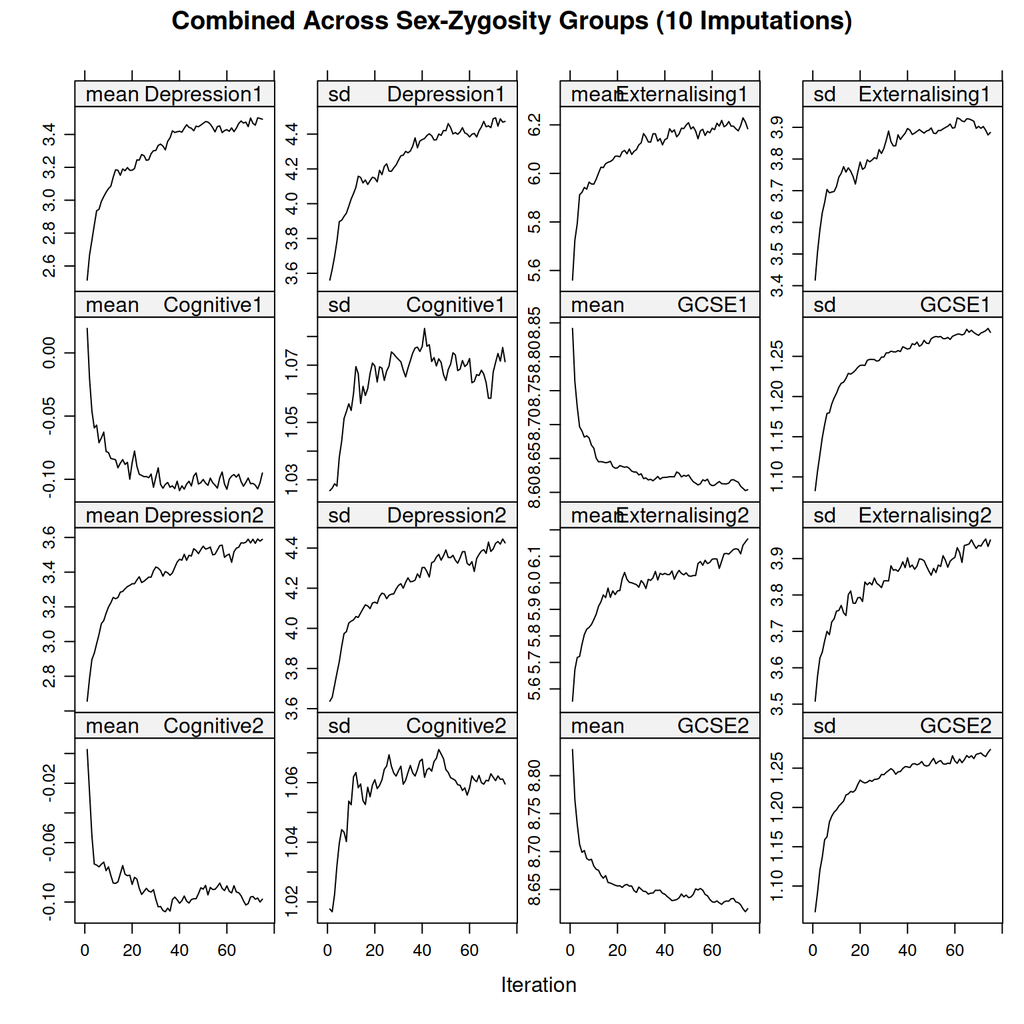

```r
ids = tasks %>%
  filter(imputation <= 10) %>%
  filter(timepoint == rq1y_twin[1]) %>%
  pull(i)

combine_mids = Reduce(mice::rbind, all_imputations[ids])

combine_mids %>%
  rename_mids() %>%
  plot(y = new_names, layout = c(4, 4), main = "Combined Across Sex-Zygosity Groups (10 Imputations)")
```

#### Timepoint: Y26 (TEDS26 questionnaire)

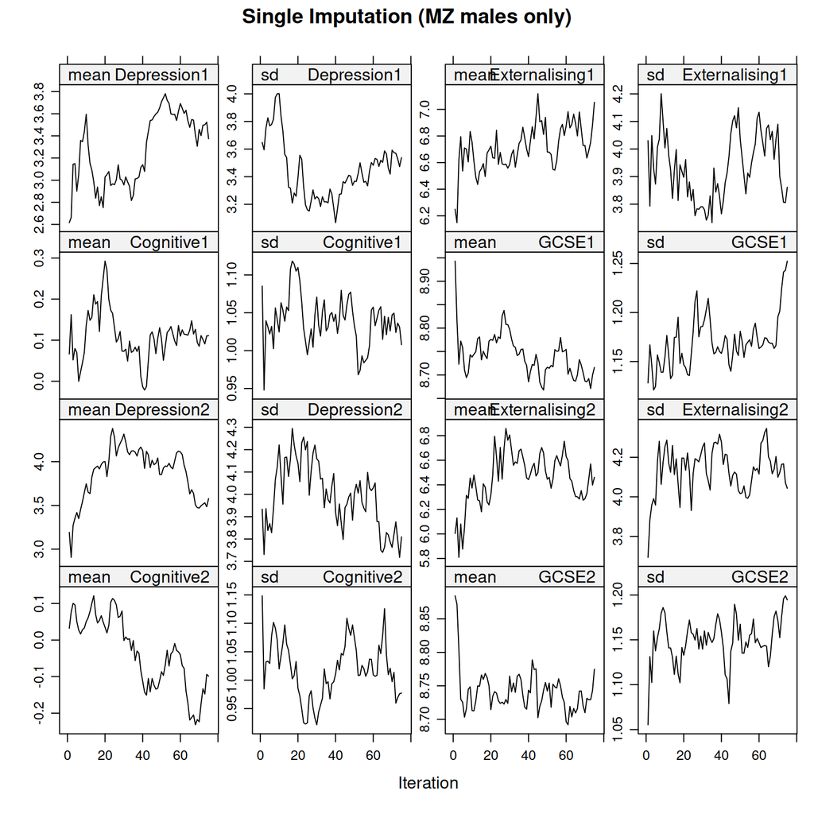

```r
ids = tasks %>%
  filter(imputation == 1) %>%
  filter(timepoint == rq1y_twin[2]) %>%
  pull(i)

combine_mids = Reduce(mice::rbind, all_imputations[ids])

all_imputations[[ids[1]]] %>%
  rename_mids() %>%
  plot(y = new_names, layout = c(4, 4), main = "Single Imputation (MZ males only)")
```

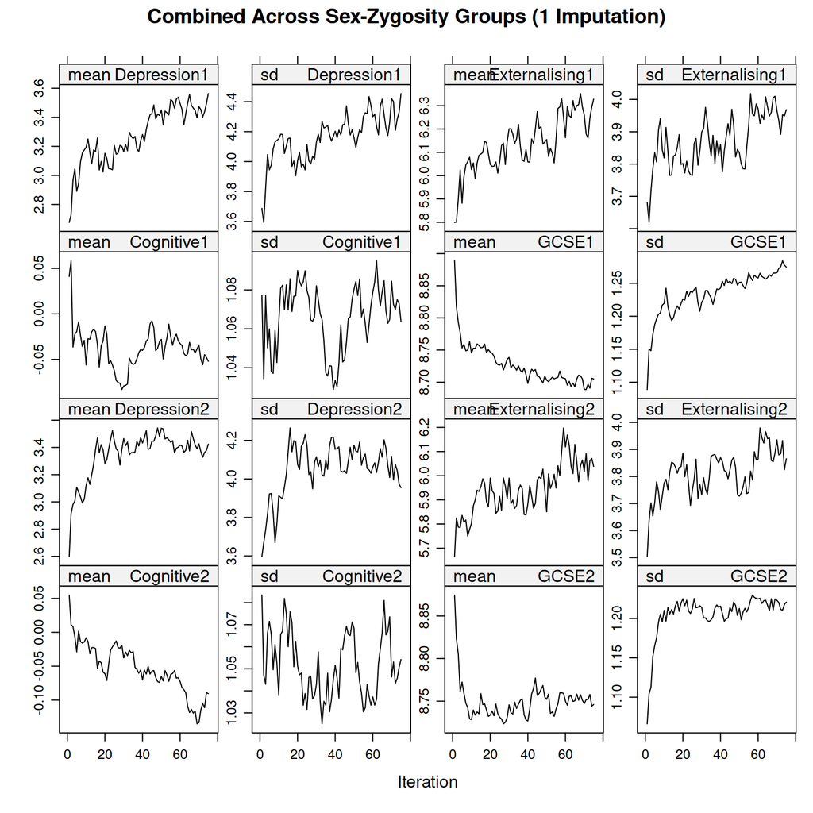

```r
combine_mids %>%
  rename_mids() %>%
  plot(y = new_names, layout = c(4, 4), main = "Combined Across Sex-Zygosity Groups (1 Imputation)")
```

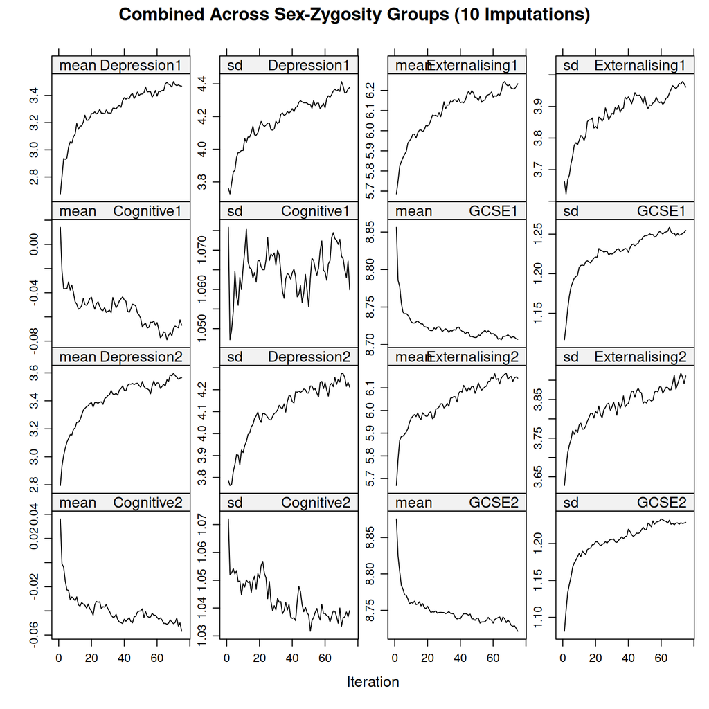

```r
ids = tasks %>%
  filter(imputation <= 10) %>%
  filter(timepoint == rq1y_twin[2]) %>%
  pull(i)

combine_mids = Reduce(mice::rbind, all_imputations[ids])

combine_mids %>%
  rename_mids() %>%
  plot(y = new_names, layout = c(4, 4), main = "Combined Across Sex-Zygosity Groups (10 Imputations)")
```

#### Timepoint: Y26 (CATSLife web tests)

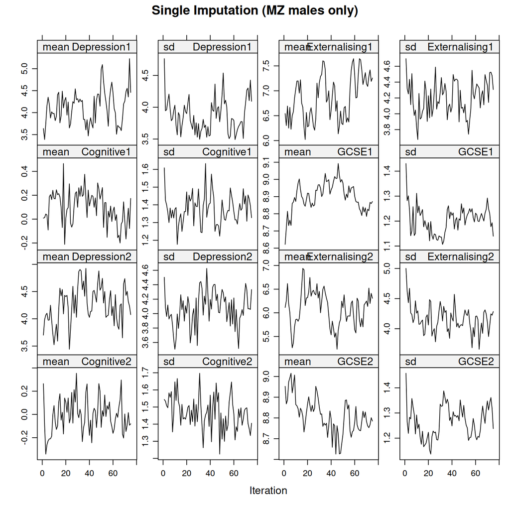

```r
ids = tasks %>%
  filter(imputation == 1) %>%
  filter(timepoint == rq1y_twin[3]) %>%
  pull(i)

combine_mids = Reduce(mice::rbind, all_imputations[ids])

all_imputations[[ids[1]]] %>%
  rename_mids() %>%
  plot(y = new_names, layout = c(4, 4), main = "Single Imputation (MZ males only)")
```

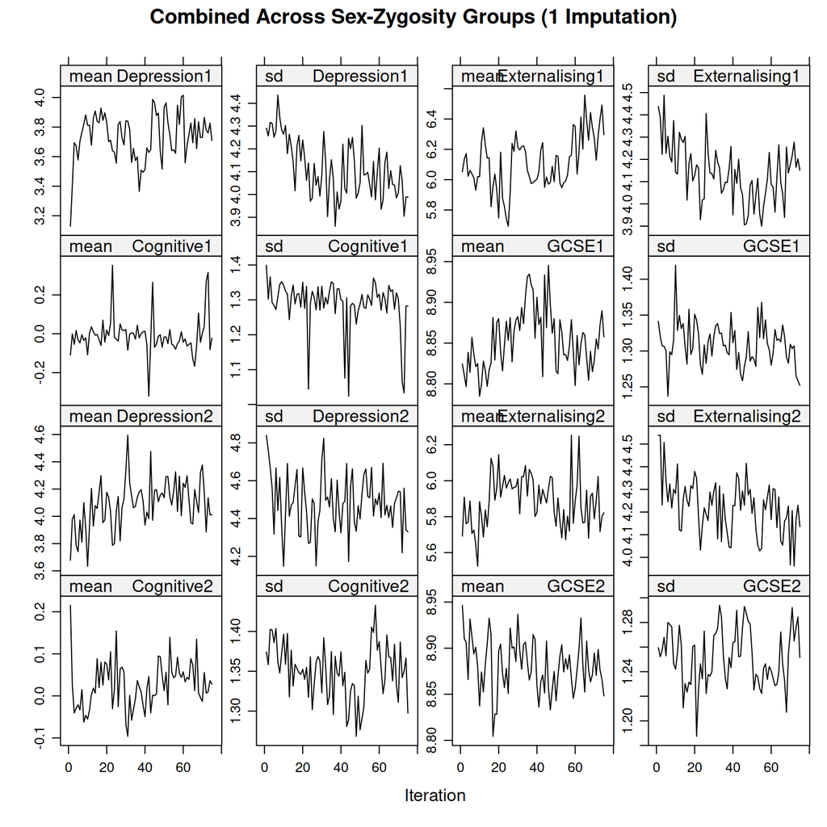

```r
combine_mids %>%
  rename_mids() %>%
  plot(y = new_names, layout = c(4, 4), main = "Combined Across Sex-Zygosity Groups (1 Imputation)")
```

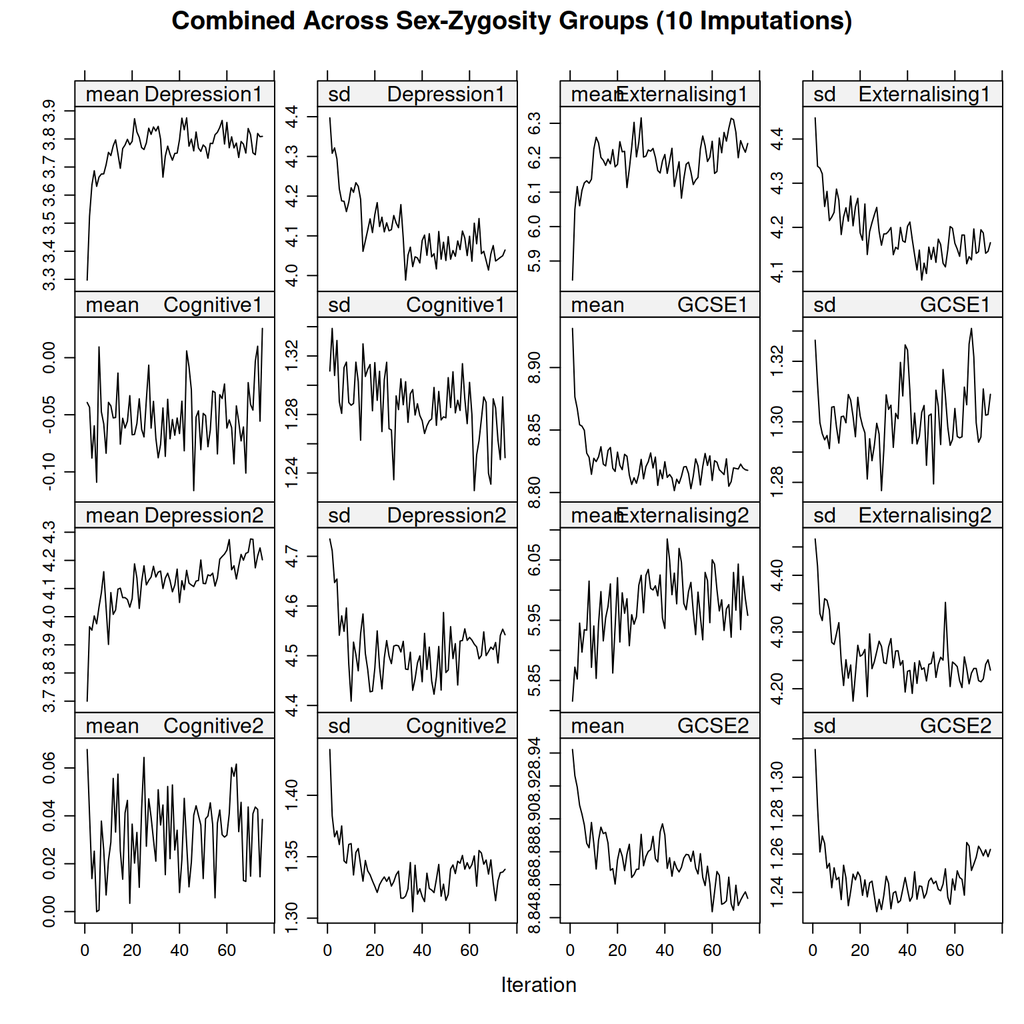

```r
ids = tasks %>%
  filter(imputation <= 10) %>%
  filter(timepoint == rq1y_twin[3]) %>%
  pull(i)

combine_mids = Reduce(mice::rbind, all_imputations[ids])

combine_mids %>%
  rename_mids() %>%
  plot(y = new_names, layout = c(4, 4), main = "Combined Across Sex-Zygosity Groups (10 Imputations)")
```

### Convergence: pooled across all imputations (outcomes and auxiliary variables)

The plots above show only the outcomes, for 1 or 10 imputations. Here, the chain means and SDs (`chainMean`, `chainVar`) of the outcomes and of every imputed auxiliary variable (including the PGS) are pooled across all 250 imputations and the sex-zygosity groups, at each iteration. The pooled mean is the mean of the chain means, weighted by the number of imputed cells in each group (as `mice::rbind` does for the combined plots above). The pooled SD is the SD of all imputed values, pooled from the chain means and SDs (within + between chains; `mice::rbind` averages only the within-chain variances). For twin-specific auxiliary variables only the twin 1 version is shown (the co-twin PGS are not imputed in the MZ groups). Auxiliary variables without missing data are not imputed and are not shown. The same plots for the quickpred imputation are in `15_quickpred_5_imputation_diagnostics.qmd`.

```r
tp_labels = setNames(rq1y_twin_labels_clean_extrashort, rq1y_twin)

# Chain means and SDs of `vars`, for every mids object (one per imputation x sex-zygosity group x time point),
# with the number of imputed cells per variable (used to pool the groups)
extract_traces = function(all_imputations, tasks, vars) {
  map_dfr(tasks$i, function(k) {
    mids_obj = all_imputations[[k]]
    v        = intersect(vars, dimnames(mids_obj$chainMean)[[1]])
    n_iter   = dim(mids_obj$chainMean)[2]
    tibble(
      var       = rep(v, times = n_iter),
      iteration = rep(seq_len(n_iter), each = length(v)),
      mean      = as.vector(mids_obj$chainMean[v, , 1, drop = FALSE]),           # variables x iterations (m = 1 per mids object)
      sd        = sqrt(as.vector(mids_obj$chainVar[v, , 1, drop = FALSE])),
      n_imp     = rep(colSums(mids_obj$where[, v, drop = FALSE]), times = n_iter),
      task      = k
    )
  }) %>%
    left_join(tasks %>% select(i, timepoint, sexzyg, imputation), by = c("task" = "i")) %>%
    mutate(
      twin     = paste("Twin", str_extract(var, "\\d$")),
      variable = if_else(var %in% rq6y_all, rq6y_labels[match(str_remove(var, "\\d$"), rq6y_prefix)], str_remove(var, "\\d$"))
    )
}

# Pool the chains of all imputations and sex-zygosity groups at each iteration
pool_traces = function(tr) {
  tr %>%
    filter(n_imp > 0, !is.na(mean)) %>%
    group_by(timepoint, var, variable, twin, iteration) %>%
    summarise(
      Mean = weighted.mean(mean, n_imp),
      SD   = sqrt(sum(n_imp * (sd^2 + (mean - Mean)^2)) / sum(n_imp)),        # total variance = within + between chains
      .groups = "drop"
    ) %>%
    pivot_longer(c(Mean, SD), names_to = "statistic") %>%
    mutate(timepoint = factor(tp_labels[timepoint], levels = rq1y_twin_labels_clean_extrashort))
}

rm(all_imputations); gc()                                                       # the convergence-setup chunk kept only the first 20 imputations
```

```
             used   (Mb) gc trigger    (Mb)   max used    (Mb)
Ncells    6031847  322.2  286750984 15314.2  271438955 14496.5
Vcells 1163455055 8876.5 3742734824 28554.9 3742733452 28554.8
```

```r
all_imputations = readRDS(file = file.path("results", "8_1_all_imputations.Rds"))
# Auxiliary variables: twin 1 version of twin-specific variables, plus family-level variables (e.g. amosoc2 has no twin 1 version)
aux_all        = c(rq6z_vars, rq6z_pgs_vars)
aux_trace_vars = aux_all[!(str_detect(aux_all, "2$") & sub("2$", "1", aux_all) %in% aux_all)]

traces          = extract_traces(all_imputations, tasks, c(rq6y_all, aux_trace_vars))
rm(all_imputations); gc()
```

```
             used    (Mb) gc trigger    (Mb)   max used    (Mb)
Ncells    6032253   322.2  369989002 19759.6  319028522 17038.0
Vcells 1470581928 11219.7 4311771316 32896.3 4488583142 34245.2
```

```r
testthat::test_that("Chain traces extracted for every task and outcome", {
  testthat::expect_equal(n_distinct(traces$task), nrow(tasks))
  o = traces %>% filter(var %in% rq6y_all)
  testthat::expect_false(anyNA(o$mean[o$n_imp > 0]))
})
```

```
Test passed 🎊
```

```r
traces_pooled = pool_traces(traces)
```

#### Outcomes

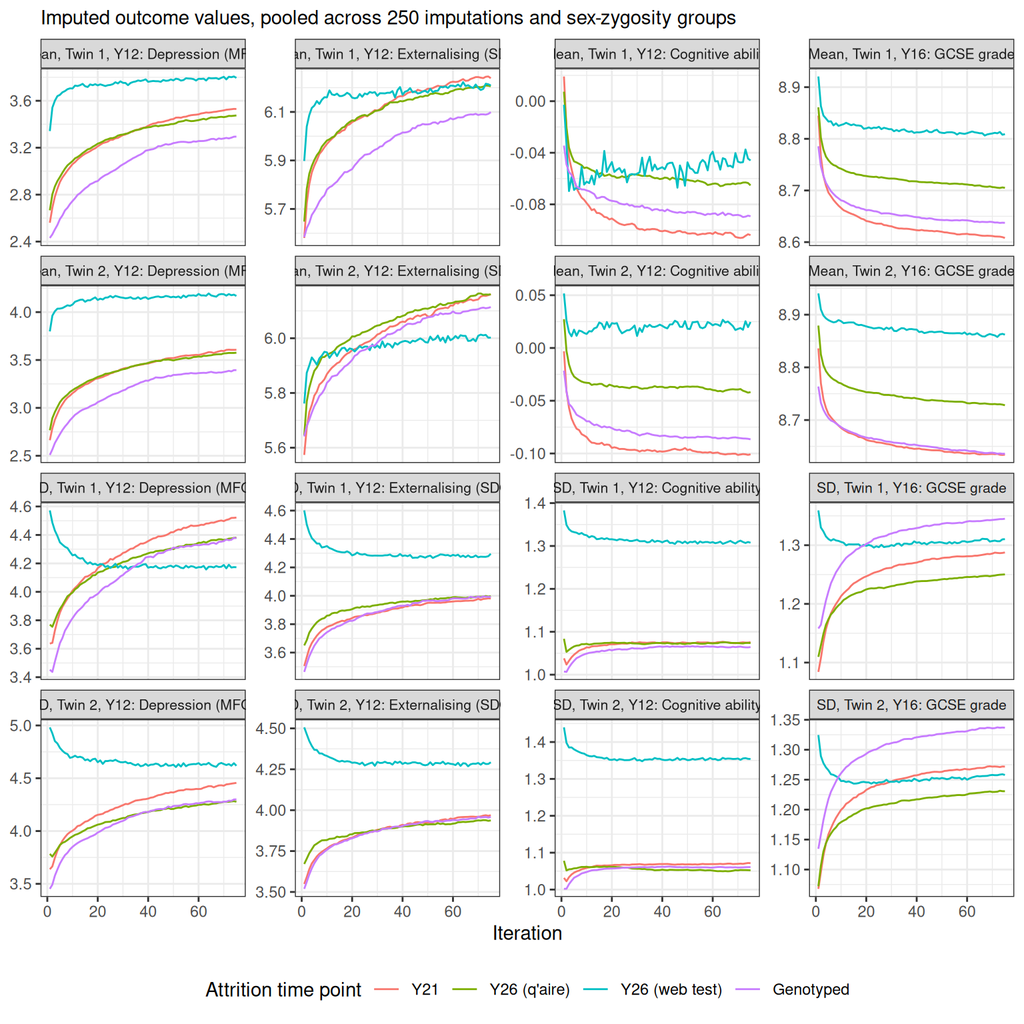

```r
traces_pooled %>%
  filter(var %in% rq6y_all) %>%
  mutate(variable = factor(variable, levels = rq6y_labels)) %>%
  ggplot(aes(x = iteration, y = value, colour = timepoint)) +
  geom_line() +
  facet_wrap(statistic + twin ~ variable, scales = "free_y", ncol = 4, labeller = labeller(.multi_line = FALSE)) +   # free y-axis in every panel
  labs(x = "Iteration", y = NULL, colour = "Attrition time point",
       title = "Imputed outcome values, pooled across 250 imputations and sex-zygosity groups") +
  theme_bw() +
  theme(legend.position = "bottom", strip.text = element_text(size = 8), plot.title = element_text(size = 11))
```

```r
save_plot("8_rq6_convergence_pooled_outcomes", width = 10, height = 8)
```

#### Auxiliary variables

The auxiliary variables (including the PGS) are not attritioned, so the four time points impute the same missing values: if the chains have converged, the lines should be flat and overlap. One panel per variable (twin 1 version for twin-specific variables), in the order of the imputation variables table; free y-axes.

```r
# Panel labels: TEDS code + short description, in the order of the imputation variables table
aux_pooled = traces_pooled %>%
  filter(var %in% aux_trace_vars) %>%
  mutate(panel = str_trunc(paste0(var, ": ", sapply(var_to_label(var), function(x) ifelse(is.null(x[1]), "", x[1]))), 45))
aux_pooled$panel = factor(aux_pooled$panel, levels = unique(aux_pooled$panel[order(match(aux_pooled$var, aux_trace_vars))]))

n_aux_panels = nlevels(aux_pooled$panel)
cat(n_aux_panels, "imputed auxiliary variables shown (of", length(aux_trace_vars), "; the others have no missing data)\n")
```

```
67 imputed auxiliary variables shown (of 70 ; the others have no missing data)
```

```r
plot_aux_traces = function(stat) {
  aux_pooled %>%
    filter(statistic == stat) %>%
    ggplot(aes(x = iteration, y = value, colour = timepoint)) +
    geom_line(linewidth = .4) +
    facet_wrap(~ panel, scales = "free_y", ncol = 6, labeller = labeller(panel = label_wrap_gen(28))) +
    labs(x = "Iteration", y = NULL, colour = "Attrition time point",
         title = paste0("Imputed auxiliary variables: pooled ", ifelse(stat == "Mean", "mean", "SD"), " across 250 imputations and sex-zygosity groups")) +
    theme_bw() +
    theme(legend.position = "top", strip.text = element_text(size = 6), axis.text = element_text(size = 6), plot.title = element_text(size = 11))
}
```

##### Mean

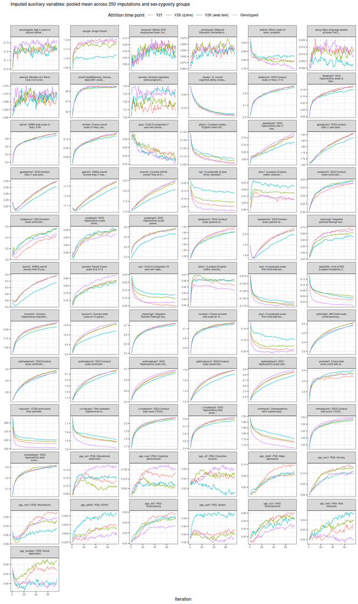

```r
plot_aux_traces("Mean")
```

```r
save_plot("8_rq6_convergence_pooled_aux_mean", width = 12, height = ceiling(n_aux_panels / 6) * 1.6 + 1)
```

##### SD

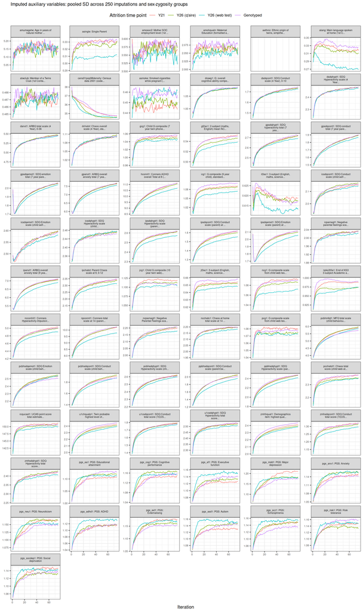

```r
plot_aux_traces("SD")
```

```r
save_plot("8_rq6_convergence_pooled_aux_sd", width = 12, height = ceiling(n_aux_panels / 6) * 1.6 + 1)
```

## Correlation Matrix of Imputation Model Variables

Correlation matrix (Pearson, pairwise complete observations) of all numeric variables included in the RQ3 multiple imputation models (see [Table of all variables used in multiple imputation (RQ3)]). Categorical/factor variables are not correlation-compatible and are excluded from the matrix below.

```r
numeric_impute_vars = rq6_imputation_vars[sapply(rq6_imputation_vars, function(v) is.numeric(df[[v]]))]

nonnumeric_impute_vars = rq6_imputation_vars[sapply(rq6_imputation_vars, function(v) !is.numeric(df[[v]]))]

df %>%
  select(all_of(nonnumeric_impute_vars)) %>%
  apply(.,2,table)
```

```
$cohort

Cohort 1: twins born Jan-94 to Aug-94 Cohort 2: twins born Sep-94 to Aug-95
                                 3650                                  4872
Cohort 3: twins born Sep-95 to Aug-96 Cohort 4: twins born Sep-96 to Dec-96
                                 5062                                  1806

$asingle

cohabiting biological mother and father / cohabiting biological parent with other
                                                                            14392
                                                                    single parent
                                                                              788

$amosoc2

                          1                           2
                       1022                        1158
                          3                           4
                       1238                        1604
                          5                           6
                        120                         860
                          7                           8
                        640                         118
                          9 caring for children at home
                        304                        6430
                     no job
                       1684

$alang

        English English + other           other
          14724             270             264

$atwclub

   0    1
9388 5450

$asmoke

    0     1
13098  2236
```

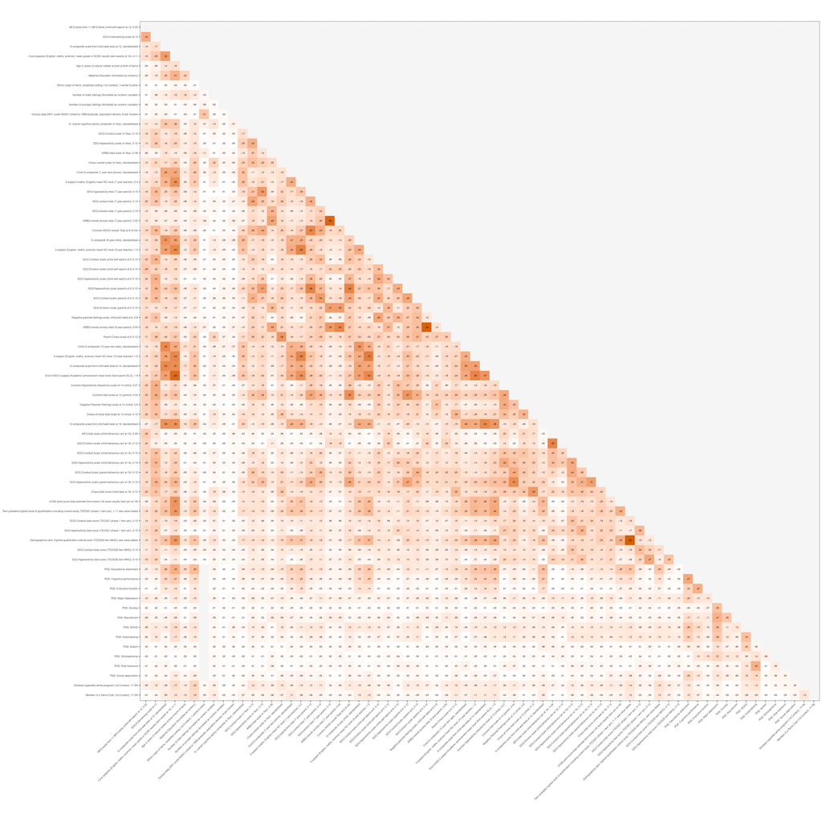

```r
cor_dat = df %>%
  select(all_of(numeric_impute_vars),"asmoke","atwclub") %>%
  mutate(
    asmoke = as.numeric(asmoke),
    atwclub = as.numeric(atwclub)
  ) %>%
  select(-ends_with("2")) %>%
  `colnames<-`(var_to_label(colnames(.)))

gbtoolbox::plot_correlations(
  cor_dat,
  text_size_r         = 1.8,
  text_size_axis      = 6,
  sample_size         = FALSE,
  confidence_interval = FALSE,
  suppress_warning_message = TRUE
)
```

```r
save_plot("8_rq6_imputation_vars_correlation_matrix", width = 18, height = 18, trim = FALSE)
```

📊 View Full Resolution Correlation Matrix (PNG)